# Project Overview

### Logistic Regression

**How does a Logistic Regression work?**

Logistic Regression is a classification algorithm that predicts the probability of an instance belonging to a certain class. It works by applying the logistic (sigmoid) function to a weighted sum of input features, producing a probability score between 0 and 1.

For multiclass classification, Logistic Regression uses the softmax function instead of the sigmoid, assigning a probability to each possible class. The model is trained by adjusting weights to minimize the difference between predicted probabilities and actual labels using optimization techniques like gradient descent.

#### Pipeline and Model Building

```python
# Define the LogisticRegression model
q1_lr = LogisticRegression(featuresCol="features", family="multinomial", labelCol="label", maxIter=20, regParam=0.3)

# Building the pipeline:
# countVectorizer -> idf -> label_indexer -> LogisticRegression
q1_pipeline_lr = Pipeline(stages=[countVectorizer, idf, label_indexer, q1_lr])

# Create a parameter grid:
# LogisticRegression tuning: regression parameter and vobabulary size
q1_paramGrid_lr = (ParamGridBuilder()
                .addGrid(countVectorizer.vocabSize, [1000, 2500, 5000])
                .addGrid(q1_lr.regParam, [0.01, 0.1, 1.0])
                .build())

# Create the CrossValidator for LogisticRegression
# Evaluator = accuracy (metric the CV try to maximize)
q1_crossval_lr = CrossValidator(estimator=q1_pipeline_lr,
                             estimatorParamMaps=q1_paramGrid_lr,
                             evaluator=accuracy_evaluator,
                             numFolds=2)
```

#### Checkpoint

```python
# Define model path
modelspath = "./models/"
q1_lr_path = f"{modelspath}q1_cvmodel_lr"

try:
    # Checkpoint for Model
    # 1. Import existing model if available
    # 2. If no existing model run the above definded model on the test data and afterwards save model
    if os.path.exists(q1_lr_path):
        print(f"Loading model from {q1_lr_path}")
        # Load pretrained model from path
        q1_cvmodel_lr = CrossValidatorModel.load(q1_lr_path)
    else:
        print("Model not found. Training model...")
        # Train model on train data
        q1_cvmodel_lr = q1_crossval_lr.fit(q1_train_df)
        # Save trained model to path
        q1_cvmodel_lr.write().overwrite().save(q1_lr_path)
        print(f"Saved model to {q1_lr_path}")
except Exception as e:
    print(f"An error occurred during model loading/training/saving: {e}")
```

```
Loading model from ./models/q1_cvmodel_lr
```

#### Predictions and Metrics

```python
# Generate predictions on the test data
q1_predictions_lr = q1_cvmodel_lr.transform(q1_test_df)

# Evaluate the model using the evaluators
q1_accuracy_lr = accuracy_evaluator.evaluate(q1_predictions_lr)
q1_precision_lr = precision_evaluator.evaluate(q1_predictions_lr)
q1_recall_lr = recall_evaluator.evaluate(q1_predictions_lr)
q1_f1_score_lr = f1_evaluator.evaluate(q1_predictions_lr)

# Create and print metrics DataFrame for LogisticRegression
q1_metrics_schema = ["Metric", "Value"]
q1_metrics_lr = [
    ("Accuracy", round(q1_accuracy_lr, 2)),
    ("Precision", round(q1_precision_lr, 2)),
    ("Recall", round(q1_recall_lr, 2)),
    ("F1 Score", round(q1_f1_score_lr, 2)),
]
q1_metrics_lr = spark.createDataFrame(q1_metrics_lr, q1_metrics_schema)

print("Q1 Metrics for Logistic Regression:")
q1_metrics_lr.show(truncate=False)
```

```
Q1 Metrics for Logistic Regression:
+---------+-----+
|Metric   |Value|
+---------+-----+
|Accuracy |0.87 |
|Precision|0.88 |
|Recall   |0.87 |
|F1 Score |0.87 |
+---------+-----+
```

### Naive Bayes

**How does the Naive Bayes work?**

Naive Bayes is a probabilistic classification algorithm based on Bayes' theorem, which calculates the probability of a class given the input features. It assumes that all features are independent (hence "naive") and contribute equally to the classification, making it computationally efficient.

For multiclass classification, Naive Bayes estimates the probability of each class using the frequency of words in the training data. The model applies the multinomial distribution, which is commonly used for text classification tasks like spam filtering and language detection. The smoothing parameter (smoothing=1.0) prevents zero probabilities by assigning small values to unseen words, improving generalization.

#### Pipeline and Model Building

```python
# Define the NaiveBayes model
q1_nb = NaiveBayes(featuresCol="features", labelCol="label", smoothing=1.0, modelType="multinomial")

# Building the pipeline:
# countVectorizer -> idf -> label_indexer -> NaiveBayes
q1_pipeline_nb = Pipeline(stages=[countVectorizer, idf, label_indexer, q1_nb])

# Create a parameter grid:
# Naive Bayes tuning: smoothing parameter and vobabulary size
q1_paramGrid_nb = (ParamGridBuilder()
                   .addGrid(countVectorizer.vocabSize, [1000, 2500, 5000])
                   .addGrid(q1_nb.smoothing, [0.5, 1.0, 1.5])
                   .build())

# Create the CrossValidator for NaiveBayes
# Evaluator = accuracy (metric the CV try to maximize)
q1_crossval_nb = CrossValidator(estimator=q1_pipeline_nb,
                                estimatorParamMaps=q1_paramGrid_nb,
                                evaluator=accuracy_evaluator,
                                numFolds=2)
```

#### Checkpoint

```python
# Define model path
modelspath = "./models/"
q1_nb_path = f"{modelspath}q1_cvmodel_nb"

try:
    # Checkpoint for Model
    # 1. Import existing model if available
    # 2. If no existing model run the above definded model on the test data and afterwards save model
    if os.path.exists(q1_nb_path):
        print(f"Loading model from {q1_nb_path}")
        # Load pretrained model from path
        q1_cvmodel_nb = CrossValidatorModel.load(q1_nb_path)
    else:
        print("Model not found. Training model...")
        # Train model on train data
        q1_cvmodel_nb = q1_crossval_nb.fit(q1_train_df)
        # Save trained model to path
        q1_cvmodel_nb.write().overwrite().save(q1_nb_path)
        print(f"Saved model to {q1_nb_path}")
except Exception as e:
    print(f"An error occurred during model loading/training/saving: {e}")
```

```
Loading model from ./models/q1_cvmodel_nb
```

#### Predictions and Metrics

```python
# Generate predictions on the test data
q1_predictions_nb = q1_cvmodel_nb.transform(q1_test_df)

# Evaluate the model using the evaluators
q1_accuracy_nb   = accuracy_evaluator.evaluate(q1_predictions_nb)
q1_precision_nb  = precision_evaluator.evaluate(q1_predictions_nb)
q1_recall_nb     = recall_evaluator.evaluate(q1_predictions_nb)
q1_f1_score_nb   = f1_evaluator.evaluate(q1_predictions_nb)

# Create and print overall metrics DataFrame for NaiveBayes
q1_metrics_schema = ["Metric", "Value"]
q1_metrics_nb = [
    ("Accuracy", round(q1_accuracy_nb, 2)),
    ("Precision", round(q1_precision_nb, 2)),
    ("Recall", round(q1_recall_nb, 2)),
    ("F1 Score", round(q1_f1_score_nb, 2)),
]
q1_metrics_nb = spark.createDataFrame(q1_metrics_nb, q1_metrics_schema)

print("Q1 Metrics for Naive Bayes:")
q1_metrics_nb.show(truncate=False)
```

```
Q1 Metrics for Naive Bayes:
+---------+-----+
|Metric   |Value|
+---------+-----+
|Accuracy |0.84 |
|Precision|0.86 |
|Recall   |0.84 |
|F1 Score |0.85 |
+---------+-----+
```

### Random Forest Classifier

**How does a Random Forest Classifier work?**

Random Forest is an ensemble learning method that combines multiple decision trees to improve classification performance. Each tree in the forest is trained on a random subset of the data (using bootstrapping) and makes an independent prediction. The final classification is determined by majority voting, where the most frequently predicted class is selected.

For multiclass classification, Random Forest builds multiple decision trees that split the data based on the most informative features at each step. This method reduces overfitting compared to a single decision tree and increases generalization. Random Forest also supports feature importance scoring, helping to identify the most influential variables in the dataset.

#### Pipeline and Model Building

```python
# Define the RandomForest model
q1_rf = RandomForestClassifier(featuresCol="features", labelCol="label")

# Building the pipeline:
# countVectorizer -> idf -> label_indexer -> RandomForest
q1_pipeline_rf = Pipeline(stages=[countVectorizer, idf, label_indexer, q1_rf])

# Create a parameter grid:
# Random Forest tuning: number of trees and max depth
q1_paramGrid_rf = (ParamGridBuilder()
                   .addGrid(q1_rf.numTrees, [10, 20, 30])
                   .addGrid(q1_rf.maxDepth, [5, 10, 15])
                   .build())

# Create the CrossValidator for RandomForest
# Evaluator = accuracy (metric the CV try to maximize)
q1_crossval_rf = CrossValidator(estimator=q1_pipeline_rf,
                                estimatorParamMaps=q1_paramGrid_rf,
                                evaluator=accuracy_evaluator,
                                numFolds=2)
```

#### Checkpoint

```python
# Define model path
modelspath = "./models/"
q1_rf_path = f"{modelspath}q1_cvmodel_rf"

try:
    # Checkpoint for Model
    # 1. Import existing model if available
    # 2. If no existing model run the above defined model on the test data and afterwards save model
    if os.path.exists(q1_rf_path):
        print(f"Loading model from {q1_rf_path}")
        # Load pretrained model from path
        q1_cvmodel_rf = CrossValidatorModel.load(q1_rf_path)
    else:
        print("Model not found. Training model...")
        # Train model on train data
        q1_cvmodel_rf = q1_crossval_rf.fit(q1_train_df)
        # Save trained model to path
        q1_cvmodel_rf.write().overwrite().save(q1_rf_path)
        print(f"Saved model to {q1_rf_path}")
except Exception as e:
    print(f"An error occurred during model loading/training/saving: {e}")
```

```
Loading model from ./models/q1_cvmodel_rf
```

#### Predictions and Metrics

```python
# Generate predictions on the test data
q1_predictions_rf = q1_cvmodel_rf.transform(q1_test_df)

# Evaluate the model using the evaluators
q1_accuracy_rf   = accuracy_evaluator.evaluate(q1_predictions_rf)
q1_precision_rf  = precision_evaluator.evaluate(q1_predictions_rf)
q1_recall_rf     = recall_evaluator.evaluate(q1_predictions_rf)
q1_f1_score_rf   = f1_evaluator.evaluate(q1_predictions_rf)

# Create and print overall metrics DataFrame for Random Forest
q1_metrics_schema = ["Metric", "Value"]
q1_metrics_rf = [
    ("Accuracy", round(q1_accuracy_rf, 2)),
    ("Precision", round(q1_precision_rf, 2)),
    ("Recall", round(q1_recall_rf, 2)),
    ("F1 Score", round(q1_f1_score_rf, 2)),
]
q1_metrics_rf = spark.createDataFrame(q1_metrics_rf, q1_metrics_schema)

print("Q1 Metrics for Random Forest:")
q1_metrics_rf.show(truncate=False)
```

```
Q1 Metrics for Random Forest:
+---------+-----+
|Metric   |Value|
+---------+-----+
|Accuracy |0.77 |
|Precision|0.83 |
|Recall   |0.77 |
|F1 Score |0.76 |
+---------+-----+
```

## Model Evaluation

### Model Comparison and Selection

#### Model Metric Comparison Chart

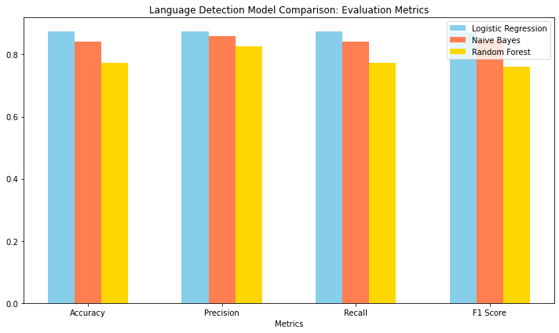

```python
# Define the model names and metrics
q1_models = ["Logistic Regression", "Naive Bayes", "Random Forest"]
q1_metrics = ["Accuracy", "Precision", "Recall", "F1 Score"]

# Define the values for each metric and model
q1_values_lr = [q1_accuracy_lr, q1_precision_lr, q1_recall_lr, q1_f1_score_lr]
q1_values_nb = [q1_accuracy_nb, q1_precision_nb, q1_recall_nb, q1_f1_score_nb]
q1_values_rf = [q1_accuracy_rf, q1_precision_rf, q1_recall_rf, q1_f1_score_rf]

# Set the positions for the bars using NumPy
q1_x = np.arange(len(q1_metrics))  # The label locations
q1_width = 0.2  # The width of the bars

# Create a figure and axis
q1_fig, q1_ax = plt.subplots(figsize=(10, 6))

# Plot the bars for each model with pastel colors
q1_ax.bar(q1_x - q1_width, q1_values_lr, q1_width, label="Logistic Regression", color="skyblue")
q1_ax.bar(q1_x, q1_values_nb, q1_width, label="Naive Bayes", color="coral")
q1_ax.bar(q1_x + q1_width, q1_values_rf, q1_width, label="Random Forest", color="gold")

# Add labels, title, and custom x-axis tick labels
q1_ax.set_xlabel("Metrics")
q1_ax.set_title("Language Detection Model Comparison: Evaluation Metrics")
q1_ax.set_xticks(q1_x)
q1_ax.set_xticklabels(q1_metrics)
q1_ax.legend()

# Display the plot
plt.tight_layout()
plt.show()
```

### Analysis of best model: Logistic Regression

```python
# Extract the best model from the cross validation
q1_bestmodel = q1_cvmodel_lr.bestModel
```

#### Predictions vs. Actual Showcase

This extracts the trained StringIndexer from the pipeline to retrieve the original language labels, then applies IndexToString to convert numeric predictions back into human-readable text labels, and finally displays the TextTokens, PrimaryLanguage (actual), and PredictedLanguage (model output) for comparison.

```python
# Extract the StringIndexer stage (the third stage [2] in the pipeline)
q1_lr_labelindexer = q1_bestmodel.stages[2]

# Create an IndexToString transformer to convert numeric labels back to original text
q1_index_to_string = IndexToString(inputCol="prediction", outputCol="PredictedLanguage", labels=q1_lr_labelindexer.labels)

# Apply the transformation on the predictions DataFrame
q1_predictions_lr = q1_index_to_string.transform(q1_predictions_lr)

q1_predictions_lr.sample(fraction=0.01, seed = 1234).select("TextTokens", "PrimaryLanguage", "PredictedLanguage").show(20)
```

```
+--------------------+---------------+-----------------+
|          TextTokens|PrimaryLanguage|PredictedLanguage|
+--------------------+---------------+-----------------+
|[gas, web, app, s...|     javascript|       javascript|
|[run, javascript,...|     javascript|       javascript|
|[generate, data, ...|             c#|               c#|
|[create, private,...|     javascript|       javascript|
|[aws, createcerti...|           java|             java|
|[diamond, operato...|           java|             java|
|[pas, parameter, ...|         python|           python|
|[serve, coordinat...|     javascript|           python|
|[fix, connect, se...|         python|           python|
|[hide, parent, cl...|            c++|              c++|
|[pyrogram, teleth...|         python|           python|
|[case, insensitiv...|     javascript|       javascript|
|[detect, miss, cl...|         python|           python|
|[access, android,...|             go|               go|
|[expand, product,...|         python|           python|
|[understand, erro...|         python|           python|
|[onended, event, ...|     javascript|       javascript|
|[trouble, add, co...|         python|           python|
|[dracoloader, rea...|     javascript|       javascript|
|[run, script, dep...|             c#|               c#|
+--------------------+---------------+-----------------+
only showing top 20 rows
```

#### Predictions vs. Actual Graph

This groups and counts occurrences of predicted and actual programming languages, stores them in dictionaries for easy lookups, then creates a side-by-side bar chart to visually compare the distribution of predicted vs. actual classifications.

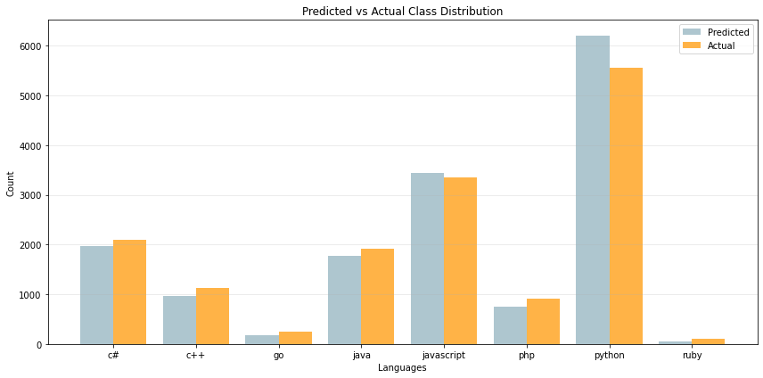

```python
# Group predictions by "PredictedLanguage" and "PrimaryLanguage" to get their counts
q1_bestmodel_predicted_counts = q1_predictions_lr.groupBy("PredictedLanguage").count().collect()
q1_bestmodel_actual_counts = q1_predictions_lr.groupBy("PrimaryLanguage").count().collect()

# Convert these counts into dictionaries for lookups
q1_predicted_dict = {row["PredictedLanguage"]: row["count"] for row in q1_bestmodel_predicted_counts}
q1_actual_dict = {row["PrimaryLanguage"]: row["count"] for row in q1_bestmodel_actual_counts}

# Combine all languages from both predicted and actual sets, then sort them for consistent ordering
q1_all_languages = sorted(set(q1_predicted_dict.keys()).union(q1_actual_dict.keys()))

# Build parallel lists of predicted and actual counts in the same order
q1_predicted_values = [q1_predicted_dict.get(lang, 0) for lang in q1_all_languages]
q1_actual_values = [q1_actual_dict.get(lang, 0) for lang in q1_all_languages]

# Create bar chart using NumPy for positioning next to each other
q1_x = np.arange(len(q1_all_languages))
q1_bar_width = 0.4

plt.figure(figsize=(12, 6))

# Plot the "Predicted" and "Actual" bars with offset for side-by-side comparison
plt.bar(
    q1_x - q1_bar_width / 2,
    q1_predicted_values,
    q1_bar_width,
    label="Predicted",
    color="#AEC6CF"
)
plt.bar(
    q1_x + q1_bar_width / 2,
    q1_actual_values,
    q1_bar_width,
    label="Actual",
    color="#FFB347"
)

# Add chart labels, title, legend, and optional grid for clarity
plt.xlabel("Languages")
plt.ylabel("Count")
plt.title("Predicted vs Actual Class Distribution")
plt.xticks(q1_x, q1_all_languages, rotation=0)
plt.legend()
plt.grid(axis="y", alpha=0.3)
plt.tight_layout()
plt.show()
```

The bar chart highlights the differences between the model’s predictions and the actual language labels, showing that while many predictions align well, some discrepancies exist, particularly in Python, Java, and C++, which could indicate areas where the model confuses similar programming languages.

#### Top 10 predictors (words) for each language

```python
import numpy as np
from pyspark.sql.types import StructType, StructField, StringType, IntegerType, FloatType

# The pipeline stages for the LogisticRegression were:
#  0: CountVectorizerModel
#  1: IDFModel
#  2: StringIndexerModel (for labels)
#  3: LogisticRegressionModel

# Get the vocabulary from the CountVectorizer
q1_bestmodel_cv = q1_bestmodel.stages[0]
q1_bestmodel_vocab = q1_bestmodel_cv.vocabulary

# Get the label mapping from the StringIndexer
label_indexer = q1_bestmodel.stages[2]
languages = label_indexer.labels

# Get the coefficient matrix from the LogisticRegression
lr_model = q1_bestmodel.stages[3]
coef_matrix = lr_model.coefficientMatrix.toArray()

# Find top 10 words ranked by coefficient value for each languageFor each language
top_words_by_language = {}
for idx, language in enumerate(languages):
    # Get indices of the top 10 coefficients in descending order
    top10_indices = np.argsort(coef_matrix[idx])[::-1][:10]
    # Map indices to words
    top_words_by_language[language] = [q1_bestmodel_vocab[i] for i in top10_indices]

# Each row is a dictionary with key "rank" and one key for each language.
data = []
for rank in range(10):
    row = [rank + 1]  # first column: rank
    for language in languages:
        row.append(top_words_by_language[language][rank])
    data.append(row)

# Create a spark df from the results
columns = ["rank"] + languages
top_predictors_df = spark.createDataFrame(data, columns)

top_predictors_df.show(truncate=20)
```

```
+----+-------------------+-----------+--------------------+--------------------+-----------+-----------+-----------+----------+
|rank|             python| javascript|                  c#|                java|        c++|        php|         go|      ruby|
+----+-------------------+-----------+--------------------+--------------------+-----------+-----------+-----------+----------+
|   1|modulenotfounderror| javascript|            winforms|          springboot|   iostream|       preg|     golang|       pre|
|   2|              panda|    reactjs|                 wpf|     printstacktrace|   compiles|    laravel|    structs|    belong|
|   3|                def| typescript|invalidoperatione...|                 mvn|       code|   sqlstate|      arise|      rail|
|   4|             python|setinterval|       monobehaviour|             openjdk|    getline|  wordpress|        cgo|      code|
|   5|     attributeerror|     nodejs|           dllimport|       jparepository| cmakelists|codeigniter|       gorm|   present|
|   6|        importerror|     nextjs|            filemode|        objectmapper|    fstream|    artisan|     broken|       end|
|   7|            pycharm|     splice|              blazor|interruptedexception|    hresult|   autoload|   outdated|   trivial|
|   8|  keyboardinterrupt|   getrange|                 uwp|    runtimeexception|    qstring|    foreach|      panic|initialise|
|   9|          itertools|     safari|               winui|                pojo|        cin|   eloquent|discrepancy|    refers|
|  10|           mainloop|        let|              csharp|      generationtype|reinterpret|        php|     differ|    couple|
+----+-------------------+-----------+--------------------+--------------------+-----------+-----------+-----------+----------+
```

### Results

# Task 2: Engagement Clustering

## Task Overview

This section focuses on clustering the question based on 3 choosen metrics.

Question: What internal groups consists in the StackOverflow questions?

**Machine Learning Models**  
A k-means clustering model is used for clustering the questions.

1. Vector Assembly
2. Standard Scaling

**Finding optimal k**  
To find the optimal number of clusters the following techniques are used:

1. Silhoutte Score
2. Elbow Method

## Preparation

### Import Libraries

#### Machine Learning Libraries

```python
# VectorAssembler: Combines multiple feature columns into a single feature vector
# StandardScaler: Scales features
from pyspark.ml.feature import VectorAssembler, StandardScaler

# KMeans: Implements the K-Means clustering algorithm for unsupervised learning
from pyspark.ml.clustering import KMeans, KMeansModel

# ClusteringEvaluator: Evaluates the quality of clustering using metrics like the Silhouette Score
from pyspark.ml.evaluation import ClusteringEvaluator
```

#### Other Libraries

```python
from pyspark.sql.functions import split, col, count, expr, when, array, explode, log1p, skewness, avg
import time

import matplotlib.pyplot as plt
import matplotlib.cm as cm
import matplotlib.colors as mcolors
from mpl_toolkits.mplot3d import Axes3D

import seaborn as sns
```

### Dataset Extraction and assembly

Here relevant columns are selected and a 20% sample of the dataset is taken to reduce resource usage. Also some rows are filtered out and the 2 new columns used for clustering as variables are created:

1. "ViewsPerDay": Views / Post Age
2. "EngagementRatio": (CommentCount + AnswerCount) / View Count

```python
# Extract relevant columns
q2_clustering = df_posts.select("PostAge", "ViewCount", "CommentCount", "AnswerCount", "Closed", "Score")

# Take a 20% sample for processing to reduce resource usage
q2_clustering = q2_clustering.sample(fraction=0.2, seed=1234)

# Drop all rows that have been closed (= no good representation of engagement and should be looked at seperately)
q2_clustering = q2_clustering.filter(col("Closed") != 1)
q2_clustering = q2_clustering.drop("Closed")

# Drop all rows that are younger that a week
q2_clustering = q2_clustering.filter(col("PostAge") > 7)

# Normalize views per day (avoid division by zero)
q2_clustering = q2_clustering.withColumn("ViewsPerDay", col("ViewCount") / when(col("PostAge") > 0, col("PostAge")).otherwise(1))

# Engagement Ratio
q2_clustering = q2_clustering.withColumn("EngagementRatio", (col("CommentCount") + col("AnswerCount")) / when(col("ViewCount") > 0, col("ViewCount")).otherwise(1))
```

Because there are negative values in the LogScore which should be handled somehow. A good way to do this is just to shift them. This means we take the minimum score and shift all the values by as much so that the minimum score is above 0.

```python
# Log Score
# Compute minimum score (to shift negative values)
min_score = q2_clustering.agg({"Score": "min"}).collect()[0][0]
# If the minimum score is negative, shift by |min_score| + 1
shift_value = abs(min_score) + 1 if min_score < 0 else 0
```

#### Skewness - Log Transformation

Let's check how skewed the features are to check if this needs to be adressed.

```python
q2_clustering.select(skewness("ViewsPerDay")).show()

# Calculate skewness for EngagementRatio
q2_clustering.select(skewness("EngagementRatio")).show()

# Calculate skewness for EngagementRatio
q2_clustering.select(skewness("Score")).show()
```

```
+---------------------+
|skewness(ViewsPerDay)|
+---------------------+
|    129.1878953577636|
+---------------------+

+-------------------------+
|skewness(EngagementRatio)|
+-------------------------+
|       2.5900162987327784|
+-------------------------+

+------------------+
|   skewness(Score)|
+------------------+
|17.125564901982692|
+------------------+
```

```python
# Apply the shifted log transformation
q2_clustering = q2_clustering.withColumn("LogScore", log1p(col("Score") + shift_value))
q2_clustering = q2_clustering.withColumn("LogViewsPerDay", log1p(col("ViewsPerDay")))
```

#### Distribution

```python
q2_features = [
     "LogViewsPerDay", "EngagementRatio", "LogScore"
]

q2_clustering.describe(q2_features).show()
```

```
+-------+--------------------+--------------------+------------------+
|summary|      LogViewsPerDay|     EngagementRatio|          LogScore|
+-------+--------------------+--------------------+------------------+
|  count|               84666|               84666|             84666|
|   mean|  0.5457255798679699|0.036314309058266735|2.5046574311426006|
| stddev| 0.46188708438817316| 0.04525739147604231|0.0738603873564156|
|    min|0.015113637810048172|                 0.0|0.6931471805599453|
|    max|    8.02575994674051|                0.88| 4.634728988229636|
+-------+--------------------+--------------------+------------------+
```

The ranges of the variables still vary significantly, meaning that some features may dominate others in the clustering process (e.g. EngagementRatio by the other 2). To ensure all features contribute equally, a scaling method will be applied later to standardize the feature magnitudes and improve clustering performance.

#### 3D Feature Distribution Plot

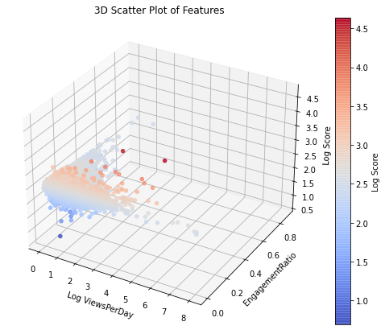

```python
q2_3d_before = q2_clustering.select(q2_features).toPandas()

fig = plt.figure(figsize=(10, 7))
ax = fig.add_subplot(111, projection='3d')

# Scatter plot
sc = ax.scatter(q2_3d_before["LogViewsPerDay"], q2_3d_before["EngagementRatio"], q2_3d_before["LogScore"],
                c=q2_3d_before["LogScore"], cmap="coolwarm", alpha=0.8)

# Labels

ax.set_xlabel("Log ViewsPerDay")
ax.set_ylabel("EngagementRatio")
ax.set_zlabel("Log Score")
ax.set_title("3D Scatter Plot of Features")

# Color bar
plt.colorbar(sc, label="Log Score")

# Show the plot
plt.show()
```

## Model Building

### Pipeline Modules

Here 2 stages used for the machine learning Pipelines are defined:

- VectorAssembler: This module combines multiple numerical features (e.g., log-transformed views, engagement ratio, and log score) into a single feature vector.
- StandardScaler: The StandardScaler normalizes the assembled feature vectors by removing the mean and scaling to unit variance. This ensures that all features contribute equally to the clustering algorithm, preventing dominance by features with larger scales.

```python
# Assemble Feature Vectors
q2_assembler = VectorAssembler(inputCols=q2_features, outputCol="assembled_features")
q2_df = q2_assembler.transform(q2_clustering)

# Apply Standard Scaling
q2_scaler = StandardScaler(inputCol="assembled_features", outputCol="features", withStd=True, withMean=True)
q2_df = q2_scaler.fit(q2_df).transform(q2_df)
```

### Finding best k

#### Silhouette Score

The silhouette score measures how well-separated and cohesive clusters are in a clustering model. It ranges from -1 to 1, where:

- 1 → Clusters are well-separated, and points are close to their own cluster.
- 0 → Clusters overlap, meaning points are on the boundary between clusters.
- -1 → Points are assigned to the wrong cluster.

A higher silhouette score means that the clustering is more meaningful, with well-defined groups.

```python
q2_cost = []
q2_silhouette_scores = {}

# Specify range of k, which will be tested
q2_k_values = range(2, 10)

for k in q2_k_values:
    q2_kmeans = KMeans(k=k, seed=1234, featuresCol="features")
    q2_model = q2_kmeans.fit(q2_df)

    q2_clustered = q2_model.transform(q2_df)

    q2_cost.append(q2_model.summary.trainingCost)

    q2_evaluator = ClusteringEvaluator(featuresCol="features", metricName="silhouette")
    q2_score = q2_evaluator.evaluate(q2_clustered)  # use q2_evaluator and q2_clustered here
    q2_silhouette_scores[k] = q2_score
    print(f"k={k}, Silhouette Score={q2_score:.4f}")
```

```
k=2, Silhouette Score=0.5405
k=3, Silhouette Score=0.4401
k=4, Silhouette Score=0.5438
k=5, Silhouette Score=0.4405
k=6, Silhouette Score=0.4694
k=7, Silhouette Score=0.4121
k=8, Silhouette Score=0.4402
k=9, Silhouette Score=0.4397
```

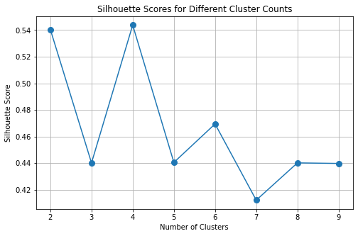

```python
# Data
q2_k_clusters = list(q2_silhouette_scores.keys())
q2_k_silhouette_scores = list(q2_silhouette_scores.values())

# Plot
plt.figure(figsize=(8, 5))
plt.plot(q2_k_clusters, q2_k_silhouette_scores, marker='o', linestyle='-', markersize=8)

plt.xlabel("Number of Clusters")
plt.ylabel("Silhouette Score")
plt.title("Silhouette Scores for Different Cluster Counts")
plt.grid(True)
```

#### Elbow Method

The elbow method is another technique used to determine the optimal number of clusters (k). It works by plotting the training cost (inertia) against different values of k.

- As k increases, the training cost decreases because clusters get smaller.
- The "elbow point" is where the rate of decrease slows down significantly, forming a bend in the curve.
- This point represents the best balance between minimizing cost and avoiding too many clusters, ensuring meaningful grouping without overfitting.

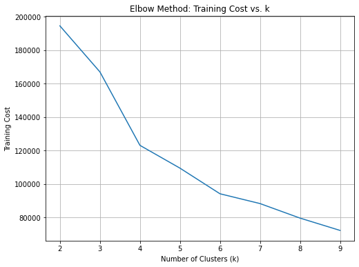

```python
k_values = list(q2_k_values)

plt.figure(figsize=(8,6))
plt.plot(k_values, q2_cost)
plt.xlabel("Number of Clusters (k)")
plt.ylabel("Training Cost")
plt.title("Elbow Method: Training Cost vs. k")
plt.grid(True)
plt.show()
```

#### Best k

The optimal number of clusters in this case is k=4 because it has the highest silhouette score (0.5438), indicating that clusters are well-separated and compact, leading to a more meaningful grouping. Additionally, the elbow method suggests that k=4 is a turning point where adding more clusters results in diminishing improvements in training cost, making it a balanced choice between interpretability and performance.

```python
q2_best_k = 4
```

### Checkpoint

```python
# Checkpoint for K-Means Model

# Define model save path
modelspath = "./models/"
q2_kmeans_path = f"{modelspath}q2_kmeans_model"

try:
    # Check if the K-Means model already exists
    if os.path.exists(q2_kmeans_path):
        print(f"Loading K-Means model from {q2_kmeans_path}")
        # Load pre-trained model
        q2_kmeans_model = KMeansModel.load(q2_kmeans_path)
    else:
        print("K-Means model not found. Training model...")

        # Train K-Means Model with chosen with best k
        q2_kmeans = KMeans(k=q2_best_k, seed=1234, featuresCol="features", predictionCol="prediction")
        q2_kmeans_model = q2_kmeans.fit(q2_df)

        # Save trained model
        q2_kmeans_model.write().overwrite().save(q2_kmeans_path)
        print(f"Saved K-Means model to {q2_kmeans_path}")

except Exception as e:
    print(f"An error occurred during K-Means model loading/training/saving: {e}")

df_clustered = q2_kmeans_model.transform(q2_df)
```

```
Loading K-Means model from ./models/q2_kmeans_model
```

## Clustering Evaluation

### Cluster Visualization

#### 3D

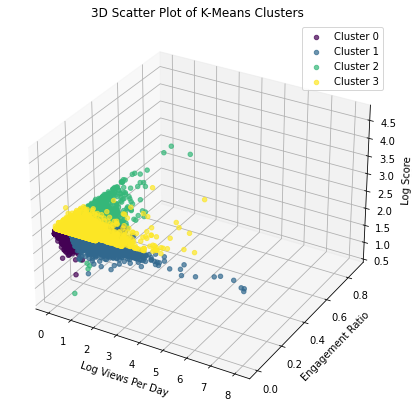

```python
# Convert to Pandas
q2_3d_after = df_clustered.select(q2_features + ["prediction"]).toPandas()

# Unique cluster labels
unique_clusters = sorted(q2_3d_after["prediction"].unique())
num_clusters = len(unique_clusters)

# Create a discrete colormap with as many colors as clusters
cmap = cm.get_cmap("viridis", num_clusters)

fig = plt.figure(figsize=(10, 7))
ax = fig.add_subplot(111, projection='3d')

# Plot each cluster separately with its own color
for i, cluster_label in enumerate(unique_clusters):
    cluster_data = q2_3d_after[q2_3d_after["prediction"] == cluster_label]
    ax.scatter(
        cluster_data["LogViewsPerDay"],
        cluster_data["EngagementRatio"],
        cluster_data["LogScore"],
        color=cmap(i),
        label=f"Cluster {cluster_label}",
        alpha=0.7
    )

ax.set_xlabel("Log Views Per Day")
ax.set_ylabel("Engagement Ratio")
ax.set_zlabel("Log Score")
ax.set_title("3D Scatter Plot of K-Means Clusters")

# Add a legend instead of a continuous color bar
ax.legend()
plt.show()
```

#### 2D

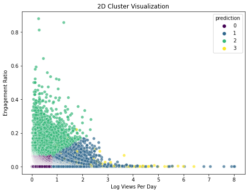

```python
pdf = df_clustered.select("LogViewsPerDay", "EngagementRatio", "prediction").toPandas()

plt.figure(figsize=(8,6))
sns.scatterplot(data=pdf, x="LogViewsPerDay", y="EngagementRatio", hue="prediction", palette="viridis", alpha=0.7)

plt.xlabel("Log Views Per Day")
plt.ylabel("Engagement Ratio")
plt.title("2D Cluster Visualization")
plt.show()
```

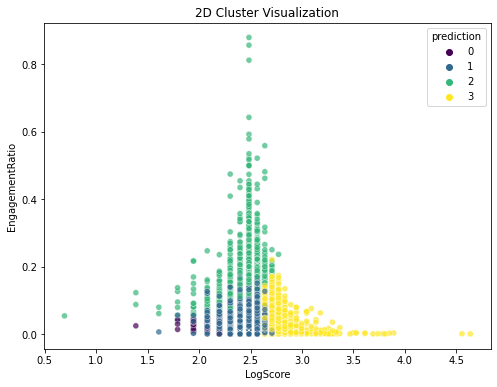

```python
pdf = df_clustered.select("LogScore", "EngagementRatio", "prediction").toPandas()

plt.figure(figsize=(8,6))
sns.scatterplot(data=pdf, x="LogScore", y="EngagementRatio", hue="prediction", palette="viridis", alpha=0.7)

plt.xlabel("LogScore")
plt.ylabel("EngagementRatio")
plt.title("2D Cluster Visualization")
plt.show()
```

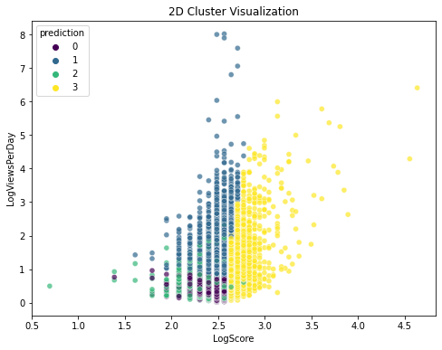

```python
pdf = df_clustered.select("LogScore", "LogViewsPerDay", "prediction").toPandas()

plt.figure(figsize=(8,6))
sns.scatterplot(data=pdf, x="LogScore", y="LogViewsPerDay", hue="prediction", palette="viridis", alpha=0.7)

plt.xlabel("LogScore")
plt.ylabel("LogViewsPerDay")
plt.title("2D Cluster Visualization")
plt.show()
```

### Cluster Metrics

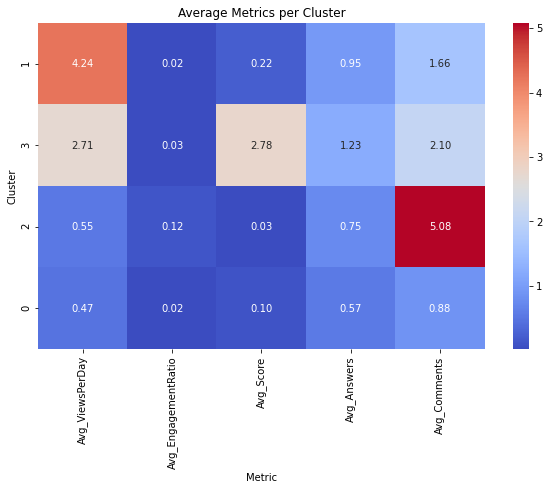

```
   prediction  Avg_ViewsPerDay  Avg_EngagementRatio  Avg_Score  Avg_Answers  \
0           1         4.240339             0.017543   0.217637     0.954439
1           3         2.711055             0.027836   2.781664     1.226216
2           2         0.548931             0.118791   0.027780     0.750288
3           0         0.473775             0.021614   0.104340     0.570184

   Avg_Comments
0      1.656224
1      2.097252
2      5.079656
3      0.876244
```

```python
# Compute average metrics per cluster
cluster_summary = df_clustered.groupBy("prediction").agg(
    avg("ViewsPerDay").alias("Avg_ViewsPerDay"),
    avg("EngagementRatio").alias("Avg_EngagementRatio"),
    avg("Score").alias("Avg_Score"),
    avg("AnswerCount").alias("Avg_Answers"),
    avg("CommentCount").alias("Avg_Comments")
)

# Convert to df
pdf_summary = cluster_summary.toPandas()

# Plot cluster summary as a heatmap
plt.figure(figsize=(10, 6))
sns.heatmap(pdf_summary.set_index("prediction"), annot=True, cmap="coolwarm", fmt=".2f")
plt.title("Average Metrics per Cluster")
plt.xlabel("Metric")
plt.ylabel("Cluster")
plt.show()

# Print table
print(pdf_summary)
```

#### Interpretation and Results

**Cluster 0: Low-Engagement, Low-Quality Questions**

- Avg_ViewsPerDay: 0.47 (Very low visibility)
- Avg_EngagementRatio: 0.0216 (Low interaction)
- Avg_Score: 0.10 (Poorly rated)
- Avg_Answers: 0.57 (Few answers)
- Avg_Comments: 0.87 (Minimal discussion)
- *Interpretation:* These questions receive little attention, few answers, and low ratings. They might be unclear, unhelpful, or niche topics with low interest.

**Cluster 1: High-View, Low-Quality Questions**

- Avg_ViewsPerDay: 4.24 (High visibility)
- Avg_EngagementRatio: 0.0175 (Extremely low interaction)
- Avg_Score: 0.22 (Low-rated)
- Avg_Answers: 0.95 (Moderate answer rate)
- Avg_Comments: 1.65 (Some discussion)
- *Interpretation:* These questions attract many views but low engagement, suggesting they may be clickbaity, unclear, or too broad.

**Cluster 2: Niche, Highly Discussed Questions**

- Avg_ViewsPerDay: 0.55 (Moderate visibility)
- Avg_EngagementRatio: 0.1188 (High interaction)
- Avg_Score: 0.03 (Very low ratings)
- Avg_Answers: 0.75 (Few answers)
- Avg_Comments: 5.08 (Extensive discussion)
- *Interpretation:* These questions don’t get many views but generate significant discussion, likely because they are opinion-based, complex, or difficult to answer.

**Cluster 3: High-Quality, Well-Engaged Questions**

- Avg_ViewsPerDay: 2.71 (Moderately high visibility)
- Avg_EngagementRatio: 0.0278 (Decent interaction)
- Avg_Score: 2.78 (Highly rated)
- Avg_Answers: 1.23 (Most likely to be answered)
- Avg_Comments: 2.09 (Active discussion)
- *Interpretation:* These are high-quality questions with good engagement, attracting both answers and discussion. They are likely well-structured, clear, and valuable to the community.

**Strengths & Shortcomings**

Overall the clustering clearly differentiates between low- vs. high-quality and low- vs. high-engagement questions. Nevertheless, there is room for improvment, which could potentially be the following:

1. Refine variables used for clustering, which means using maybe other variables or additional one's might result in better clustering.
2. Use other clustering algorithms like (DBSCAN or hierachical clustering).
3. Change the feature engineering (like log or standard scaling) to other techniques.